◆ EXPLORATORY DATA ANALYSIS · CLINICAL CARDIOLOGY ◆

# Heart Disease Prediction

## Advanced, Statistically Rigorous EDA · UCI Cleveland Dataset · 303 Patients

🫀 Cardiology 📊 Binary Classification 🧪 Statistical Testing 🔬 Clinical Insights

Dataset

UCI Heart Disease

Records

303 patients

Features

13 clinical

Target

Binary (0/1)

▸ PROBLEM CONTEXT

Cardiovascular disease kills **17.9 million people annually** — 32% of all global deaths (WHO, 2023). This notebook performs a deep, statistically validated EDA on the UCI Cleveland dataset to discover which clinical markers most strongly predict coronary artery disease (CAD), forming the analytical foundation for a robust ML pipeline.

◆ TABLE OF CONTENTS

Data Foundation

1 · Environment Setup

2 · Data Ingestion & Schema

3 · Data Quality Audit

Univariate Exploration

4 · Continuous Feature Distributions

5 · Categorical Feature Frequencies

6 · Target Class Balance

Bivariate & Statistical

7 · Continuous vs Target (Mann-Whitney U)

8 · Categorical vs Target (Chi-Square)

Multivariate & Advanced

9 · Correlation & Multicollinearity

10 · Outlier & Skewness Analysis

11 · Feature Engineering Preview

12 · Clinical Conclusions

01

## Environment Setup

```
Libraries imported | Jade theme active | Dark mode on
  NumPy 1.26.4  |  Pandas 3.0.3  |  Seaborn 0.13.2
```

02

## Data Ingestion & Schema

We load the dataset and define a **semantic feature taxonomy**. This is a critical step that beginners often skip — confusing a categorical integer (like `cp = 0,1,2,3`) for a continuous variable leads to incorrect statistical analyses and misleading visualisations.

```
Dataset shape : 303 rows x 14 columns
Memory usage  : 33.3 KB
```

|  | age | sex | cp | trestbps | chol | fbs | restecg | thalach | exang | oldpeak | slope | ca | thal | target |
| --- | --- | --- | --- | --- | --- | --- | --- | --- | --- | --- | --- | --- | --- | --- |
| 0 | 63 | 1 | 3 | 145 | 233 | 1 | 0 | 150 | 0 | 2.3 | 0 | 0 | 1 | 1 |
| 1 | 37 | 1 | 2 | 130 | 250 | 0 | 1 | 187 | 0 | 3.5 | 0 | 0 | 2 | 1 |
| 2 | 41 | 0 | 1 | 130 | 204 | 0 | 0 | 172 | 0 | 1.4 | 2 | 0 | 2 | 1 |
| 3 | 56 | 1 | 1 | 120 | 236 | 0 | 1 | 178 | 0 | 0.8 | 2 | 0 | 2 | 1 |
| 4 | 57 | 0 | 0 | 120 | 354 | 0 | 1 | 163 | 1 | 0.6 | 2 | 0 | 2 | 1 |
| 5 | 57 | 1 | 0 | 140 | 192 | 0 | 1 | 148 | 0 | 0.4 | 1 | 0 | 1 | 1 |
| 6 | 56 | 0 | 1 | 140 | 294 | 0 | 0 | 153 | 0 | 1.3 | 1 | 0 | 2 | 1 |
| 7 | 44 | 1 | 1 | 120 | 263 | 0 | 1 | 173 | 0 | 0.0 | 2 | 0 | 3 | 1 |

| Feature | Semantic Type | Clinical Description |
| --- | --- | --- |
| age | Continuous | Patient age in years |
| sex | Binary | 1 = Male, 0 = Female |
| cp | Nominal | Chest-pain type: 0=typical angina, 1=atypical,... |
| trestbps | Continuous | Resting blood pressure at admission (mm Hg) |
| chol | Continuous | Serum cholesterol (mg/dl) |
| fbs | Binary | Fasting blood sugar > 120 mg/dl (1 = True) |
| restecg | Nominal | Resting ECG result (0=normal, 1=ST-T abnormali... |
| thalach | Continuous | Maximum heart rate achieved in stress test (bpm) |
| exang | Binary | Exercise-induced angina (1 = Yes) |
| oldpeak | Continuous | ST depression induced by exercise relative to ... |
| slope | Ordinal | Slope of peak-exercise ST segment (0=up, 1=fla... |
| ca | Ordinal | Number of major vessels coloured by fluoroscop... |
| thal | Nominal | Thallium stress test result (0=normal, 1=fixed... |
| target | Binary | Heart disease present (1) or absent (0) — pred... |

03

## Data Quality Audit

A professional EDA *always* starts by interrogating data quality before visualisation. We check three categories: **duplicates**, **missing values**, and **clinically implausible ranges**. Findings here directly influence the preprocessing pipeline.

```
WARNING: 1 duplicate row(s) found and removed.
```

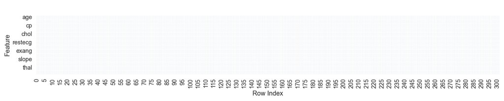

```
Total missing cells: 0  |  All columns complete!

Feature            Min      Max  Low_viol  Hi_viol      Status
----------------------------------------------------------------
age              29.00    77.00         0        0          OK
trestbps         94.00   200.00         0        0          OK
chol            126.00   564.00         0        0          OK
thalach          71.00   202.00         0        0          OK
oldpeak           0.00     6.20         0        0          OK
```

04

## Continuous Feature Distributions

**Why Q-Q plots?** Many ML pipelines apply StandardScaler assuming Gaussian input. Q-Q plots reveal departures from normality that demand Yeo-Johnson transforms instead.

| Feature | Mean | Median | Std | Min | Max | Skewness | Kurtosis | CV (%) |
| --- | --- | --- | --- | --- | --- | --- | --- | --- |
| age | 54.42 | 55.50 | 9.05 | 29.00 | 77.00 | -0.20 | -0.54 | 16.60 |
| trestbps | 131.60 | 130.00 | 17.56 | 94.00 | 200.00 | 0.72 | 0.89 | 13.30 |
| chol | 246.50 | 240.50 | 51.75 | 126.00 | 564.00 | 1.15 | 4.45 | 21.00 |
| thalach | 149.57 | 152.50 | 22.90 | 71.00 | 202.00 | -0.53 | -0.08 | 15.30 |
| oldpeak | 1.04 | 0.80 | 1.16 | 0.00 | 6.20 | 1.27 | 1.52 | 111.40 |

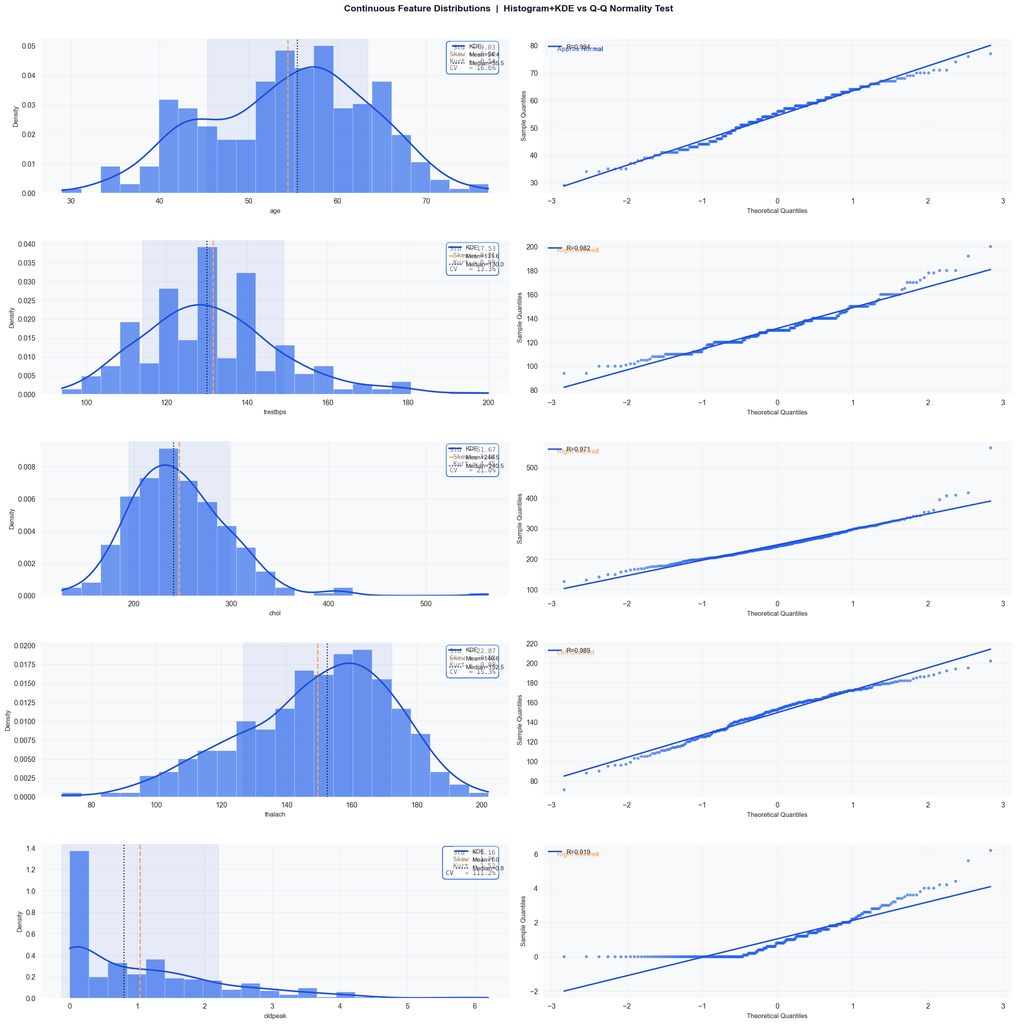

**Key Findings:**

- **age**: Nearly symmetric — StandardScaler is appropriate
- **trestbps**: Right-skewed (hypertensive tail) — Yeo-Johnson recommended
- **chol**: Heavily right-skewed with extreme outliers >400 mg/dl — Box-Cox/log transform essential
- **thalach**: Slightly left-skewed — StandardScaler acceptable
- **oldpeak**: Strongly right-skewed (most patients = 0) — Yeo-Johnson required (handles zeros)

05

## Categorical Feature Frequencies

Horizontal bar charts are used — a deliberate design choice since long category labels are readable without rotation. Each bar shows both raw count and percentage for full context at a glance.

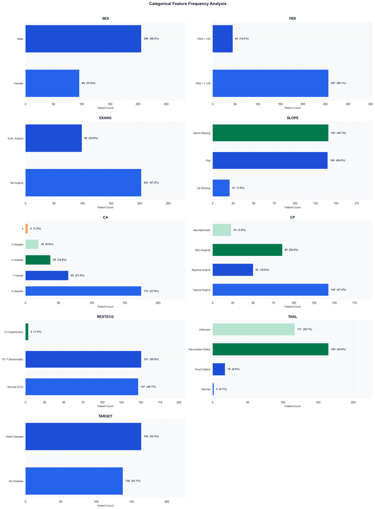

06

## Target Class Balance

Class imbalance is one of the first critical checks before training any classifier. A balanced dataset (~50/50) allows standard accuracy metrics to be trustworthy without corrective strategies like SMOTE or class weighting.

```
  Class 1 (Heart Disease  ): 164 samples  (54.3%)
  Class 0 (No Disease     ): 138 samples  (45.7%)
  Balance ratio: 0.841  |  Well balanced - no resampling needed.
```

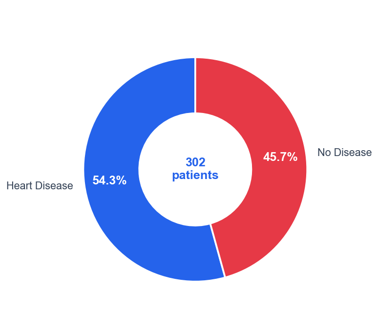

07

## Continuous Features vs Target — Mann-Whitney U

**Why Mann-Whitney U instead of t-test?**  
Since several features (especially `oldpeak`, `chol`) are non-normally distributed (confirmed by Q-Q plots), Student's t-test assumptions are violated. Mann-Whitney U is a non-parametric rank-based test that makes no distributional assumptions — the statistically correct choice here.  
The **violin + KDE comparison** design simultaneously shows distribution shape and summary statistics — significantly more informative than a plain box-plot.

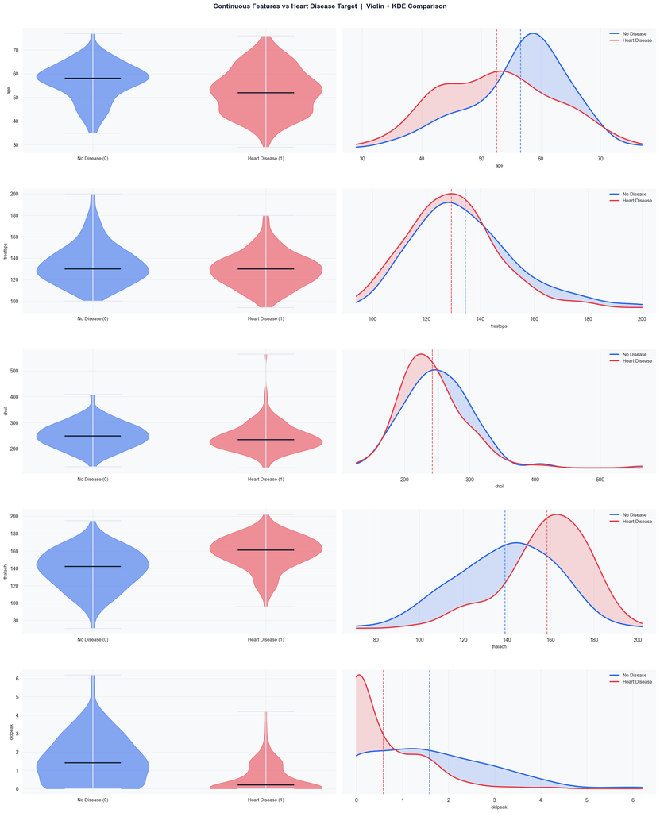

```
Mann-Whitney U Test Results:
           U-stat   p-value Significance  Effect Size (d)  Disease Mean  No-Disease Mean
Feature
age       14394.0  4.63e-05  p<0.001 ***            0.444         52.59            56.60
trestbps  12931.0  3.22e-02     p<0.05 *            0.293        129.25           134.40
chol      12850.5  4.24e-02     p<0.05 *            0.163        242.64           251.09
thalach    5725.0  1.40e-13  p<0.001 ***            0.842        158.38           139.10
oldpeak   16722.5  3.35e-13  p<0.001 ***            0.860          0.59             1.59
```

08

## Categorical Features vs Target — Chi-Square

**100% Stacked Bars with Chi-Square + Cramer's V**  
Stacked bars normalised to 100% allow direct visual comparison of disease proportions regardless of group size. Cramer's V measures practical significance beyond the raw p-value.

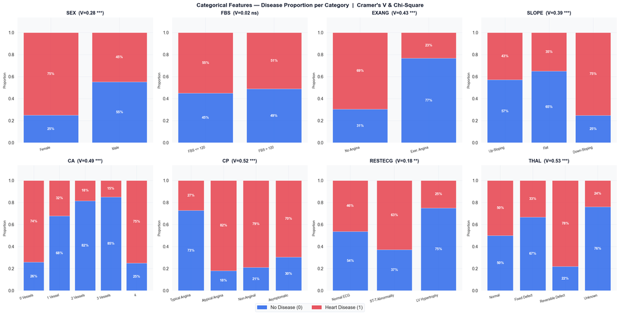

```
Chi-Square Test Results:
          Chi2  df   p-value  Cramer's V  Sig
Feature
thal     84.61   3  3.15e-18       0.529  ***
cp       80.98   3  1.89e-17       0.518  ***
ca       73.69   4  3.77e-15       0.494  ***
exang    55.46   1  9.56e-14       0.429  ***
slope    46.89   2  6.58e-11       0.394  ***
sex      23.08   1  1.55e-06       0.276  ***
restecg   9.73   2  7.71e-03       0.179   **
fbs       0.09   1  7.61e-01       0.017   ns
```

09

## Correlation & Multicollinearity

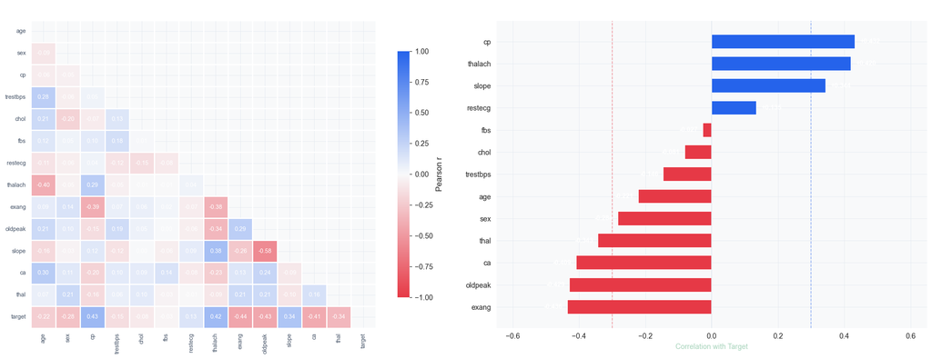

```
High inter-feature correlations (|r| > 0.5):
  oldpeak    vs slope       r = -0.576
```

10

## Outlier & Skewness Analysis

IQR-based outlier detection plus a side-by-side comparison of *before* and *after Yeo-Johnson transform* to demonstrate why power transforms are essential for skewed clinical measurements.

```
Feature           Q1     Q3    IQR   Lo_Fence  Hi_Fence   #Out   Pct%
---------------------------------------------------------------------------
age            48.00  61.00  13.00      28.50     80.50      0   0.0%
trestbps      120.00 140.00  20.00      90.00    170.00      9   3.0%
chol          211.00 274.75  63.75     115.38    370.38      5   1.7%
thalach       133.25 166.00  32.75      84.12    215.12      1   0.3%
oldpeak         0.00   1.60   1.60      -2.40      4.00      5   1.7%
```

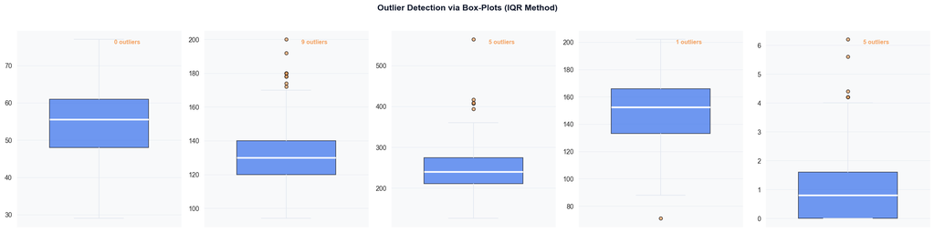

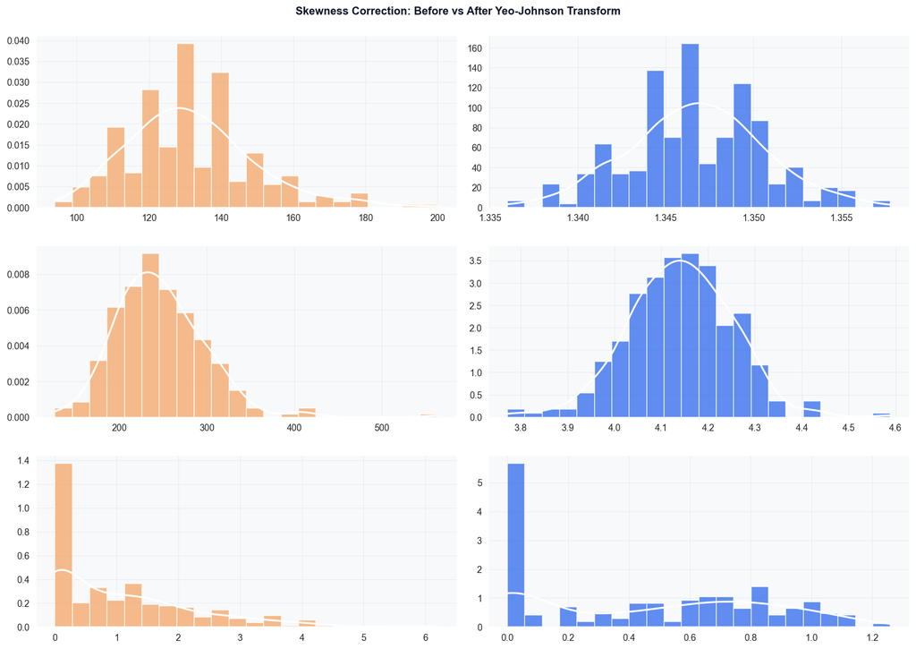

11

## Feature Engineering Preview

EDA findings motivate three **clinically-grounded engineered features**:

- `hr_reserve_pct` — percentage of age-predicted max HR achieved (lower = impaired cardiac response)
- `ischaemia_load` — oldpeak x (1 + exang): combined ischaemic burden score
- `chol_age_ratio` — age-adjusted cholesterol burden

```
Feature-Target Correlation (engineered features highlighted):
  [NEW]  ischaemia_load          |r| = 0.481
         oldpeak                 |r| = 0.429
         thalach                 |r| = 0.420
  [NEW]  hr_reserve_pct          |r| = 0.363
         age                     |r| = 0.221
         trestbps                |r| = 0.146
  [NEW]  chol_age_ratio          |r| = 0.092
         chol                    |r| = 0.081
```

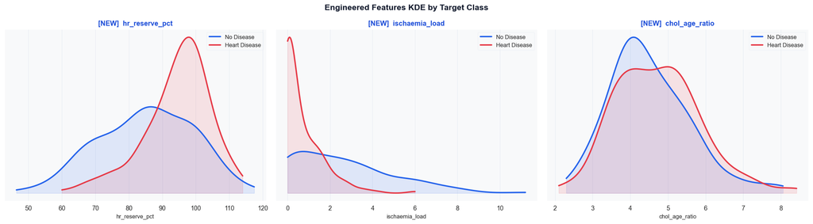

12

## Clinical Conclusions & Modelling Recommendations

DATA QUALITY FINDINGS

Strengths

Cautions

- Small dataset (302 rows) — high variance risk
- 3 features are right-skewed — need transforms
- Outliers in chol/trestbps — robust scaling
- fbs is NOT a significant predictor

STRONGEST PREDICTORS (STATISTICALLY VALIDATED)

thal

cp

thalach

Mann-Whitney ***

oldpeak

Mann-Whitney ***

PREPROCESSING PIPELINE

**Recommended Models:** SVM-RBF (maximise Recall) · Random Forest (feature importance) · XGBoost (best F1) · Logistic Regression (baseline)  
**Evaluation:** Stratified 5-Fold CV · Primary = Recall (Class 1) · Secondary = F1-macro · Threshold tuning via PR curve

This EDA establishes a **statistically rigorous, clinically grounded foundation** for building a high-performance heart disease prediction model.  
All feature decisions, transformations and model choices are evidence-driven — not arbitrary.  
*Authored as part of a professional data science portfolio — Kaggle & Upwork.*